# Complete Block Design[1]

### Introduction

#### Complete Block Design[1]

This experiment tests the effect of arrow type on hits required to kill the monster(Silver Bokoblin). Three different type of arrows were used : arrow(basic), shock arrow and freeze arrow.

[figure not shown]

[figure not shown]

- Repose : The number of shoot to kill the monster(silver Bokoblin).
- Conditions :  
  Treatment :Three different type of arrows : arrow, shock, and freeze arrow.  
  Block : 8 Different types of bows.
- Material : Battle

The hypothesis is as follows:

$$H_0: \mu_{arrow} = \mu_{shock} =\mu_{freeze}$$

$$H_a: \ \text{At least one of the population mean is different}$$

The significant level for the test:
$$\alpha = 0.05$$

**Method**

1. There are 8 types of arrows in the game. Some of the monster has resistance of cold, heat or shock. So, I choose the silver Bokoblin that doesn’t have any resistance. I played the character. I played more than 50 hrs in this game.
2. Bow is the block to reduce the variability. Used a random generator to decide which order of the bows were used and which bows will be used in the experiment(There are more than 8 type of bows in the game).
3. Save the game data before the first shoot that I can go back to the saved game data after kill the monster - for same environment for experiment. The character wears basic armor that doesn’t have any effect. Also, it wasn’t raining in the game(rain affect arrow damage).
4. Perform the experiment with the silver bokoblin. Count the number of shoots until the monster die. After kill the monster, go back to the save file and kill the monster with different arrow. The order of arrows per each block is also randomized by random generator.
5. Repeat 1-4 for other bows.

##### Zelda Data

```r
datatable(zelda)
```

|  | Arrow_type | Block | Hit |
| --- | --- | --- | --- |
| 1 | arrow | 1 | 8 |
| 2 | arrow | 2 | 14 |
| 3 | arrow | 3 | 15 |
| 4 | arrow | 4 | 44 |
| 5 | arrow | 5 | 8 |
| 6 | arrow | 6 | 11 |
| 7 | arrow | 7 | 8 |
| 8 | arrow | 8 | 42 |
| 9 | shock | 1 | 4 |
| 10 | shock | 2 | 10 |

[output cut: 14 more lines]

### Analysis

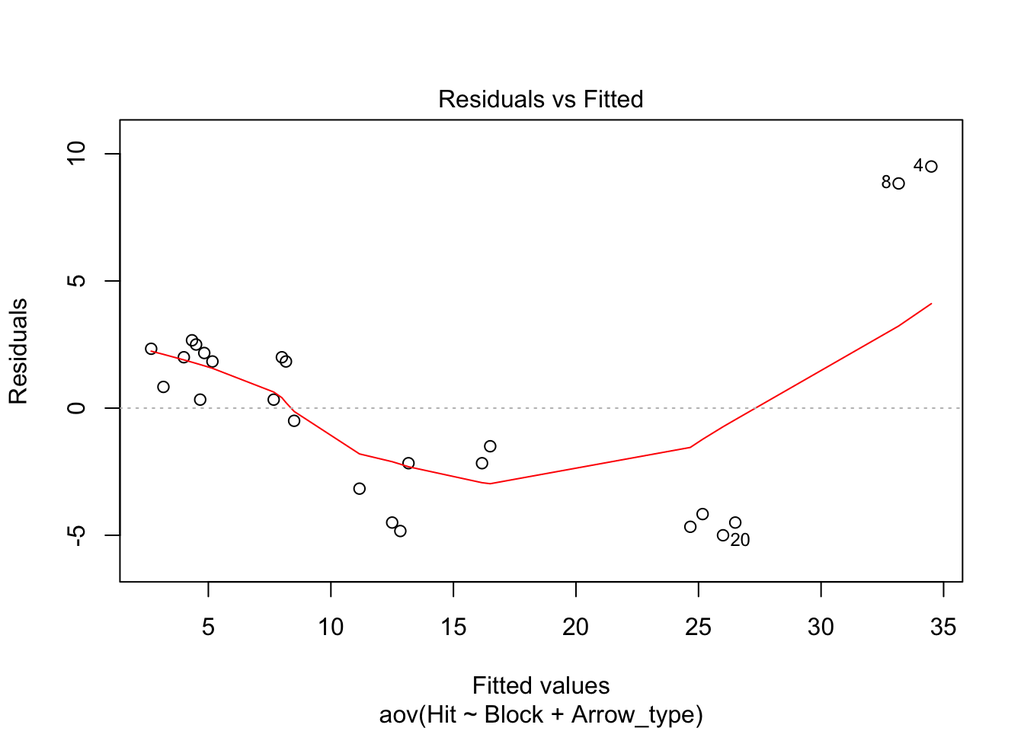

```r
zeldamod <- aov(Hit ~ Block + Arrow_type, data=zelda, contrasts = list(Block=contr.sum, Arrow_type=contr.sum))
plot(zeldamod, which=1:1)
```

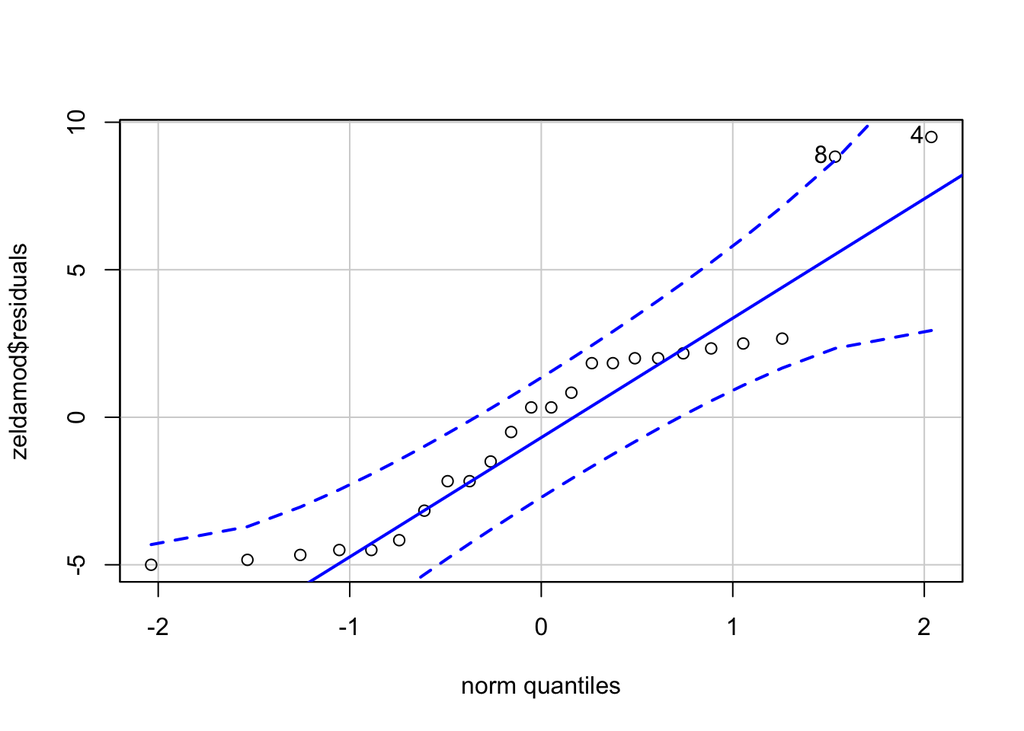

```
## [1] 4 8
```

```r
qqPlot(zeldamod$residuals)
```

With the Residual vs Fitted graph, the assumption for constant variance has issue because it has a pattern. Normal Q-Q Plot shows that assumption for normality is questionable. One dot is off from the boundary. In other words, the error terms are considered to be not normal.

```r
leveneTest(zelda$Hit , zelda$Arrow_type, center=median)
```

```
## Levene's Test for Homogeneity of Variance (center = median)
##       Df F value Pr(>F)
## group  2  1.0708 0.3607
##       21
```

P-value for Levene’s test is high enough to say treatment(arrow type) has constant variance.

```r
pander(anova(zeldamod))
```

Analysis of Variance Table

|  | Df | Sum Sq | Mean Sq | F value | Pr(>F) |
| --- | --- | --- | --- | --- | --- |
| **Block** | 7 | 1891 | 270.2 | 10.58 | 0.0001192 |
| **Arrow_type** | 2 | 364 | 182 | 7.131 | 0.007321 |
| **Residuals** | 14 | 357.3 | 25.52 | NA | NA |

Used type1 for anova test because it’s balanced data. P-value is significant(below than 0.05) for block(0.0001192) and arrow type(0.007321).

##### follow up

So, performed a *log transformation* to see if it shows better results.

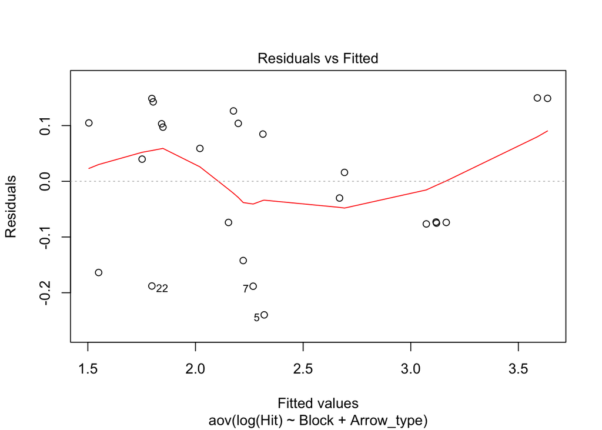

```r
myaov <- aov(log(Hit) ~ Block + Arrow_type, data=zelda)
plot(myaov, which=1)
```

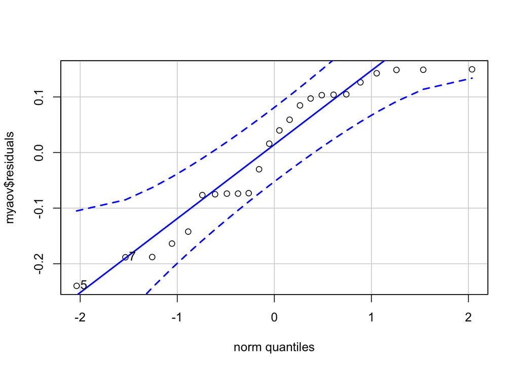

```
## [1] 5 7
```

```r
qqPlot(myaov$residuals)
```

Constant variance seems okay. Normality also looks good since all dots inside of boundaries. However, you can see some curves in the line in QQ-Plot.